# Part 2: Leveraging Machine Learning and Hyperspectral Imaging for Predicting Adulteration in Ground Arabica Coffee with Robusta: Principal Component Analysis and Clustering

Author

Derick Malavi

## Introduction

### Principal Component Analysis (PCA)

PCA reduces dimensionality in hyperspectral data by transforming the original variables into a smaller set of uncorrelated principal components. This process highlights the most significant spectral features driving variance and helps reveal relationships or adulteration patterns, even without prior labels.

PCA was applied to NIR-HSI spectral data from pure and adulterated Arabica coffee samples, reducing dimensionality while preserving critical information. The goal is to visualize the data and prepare it for further analysis using unsupervised methods like K-Means clustering.

### K-Means Clustering

K-Means clustering groups data points based on spectral similarities, offering an efficient way to identify clusters in large hyperspectral datasets. The objective is to observe whether distinct clusters for pure and adulterated coffee samples can be detected.

By applying K-Means to the PCA-transformed data, clusters corresponding to pure and adulterated coffee samples are identified based on their spectral features. This unsupervised method provides preliminary insight into the separation between pure and adulterated samples, serving as a foundation for further supervised analysis.

```r
#Load libraries

warning = FALSE
  suppressWarnings(suppressMessages({
  library(FactoMineR)
  library(factoextra)
  library(FactoInvestigate)
  library(ggplot2)
  library(dplyr)
  library(readxl)
  library(readr)
  library(janitor)
  library(mdatools)
  library(rmarkdown)
  library(knitr)
  library(quarto)
  library(pander)
  library(plotly)
  library(gridExtra)
  library(caret) #for generating confusion matrix
  }))
```

```r
# Load data preprocessed by different sepctral techniques

hsi_raw <- read.csv("coffee_data_pycleaned.csv")
hsi_snv <- read.csv("coffee_ground_snv.csv")
hsi_snv_1d <- read.csv("coffee_ground_snv_sg_1d.csv")
hsi_snv_2d <- read.csv("coffee_ground_snv_sg_2d.csv")
hsi_msc <- read.csv("coffee_ground_msc.csv")
hsi_msc_1d <- read.csv("coffee_ground_msc_sg_1d.csv")
hsi_msc_2d <- read.csv("coffee_ground_msc_sg_2d.csv")
```

```r
# Let us ensure we have the same number of dimensions and the range of our coulumns/covariates

dim(hsi_raw)
```

```
[1] 1469  229
```

```r
dim(hsi_snv)
```

```
[1] 1469  229
```

```r
dim(hsi_snv_1d)
```

```
[1] 1469  229
```

```r
dim(hsi_snv_2d)
```

```
[1] 1469  229
```

```r
dim(hsi_msc)
```

```
[1] 1469  229
```

```r
dim(hsi_msc_1d)
```

```
[1] 1469  229
```

```r
dim(hsi_msc_2d)
```

```
[1] 1469  229
```

```r
# Check a few column names
col_check <- colnames(hsi_msc[,c(1:6)])
col_check
```

```
[1] "sample_id"     "binary_class"  "three_class"   "adult_percent"
[5] "cal_val"       "X935.609985"
```

```r
# The spectral values start from column # 6-------> 229

columns <- hsi_raw[,c(1:5)]
```

### Raw Spectra (Unprocessed)

#### PCA Analysis: HSI Raw Spectral Data

```r
pca_raw <- PCA(hsi_raw[,c(6:229)],ncp = 6, graph = FALSE)

pca_raw$eig[1:5,] # Extract the first 5 component eigenvalues
```

```
        eigenvalue percentage of variance cumulative percentage of variance
comp 1 146.9369529             65.5968540                          65.59685
comp 2  71.0849617             31.7343579                          97.33121
comp 3   4.0610077              1.8129499                          99.14416
comp 4   1.2632289              0.5639415                          99.70810
comp 5   0.3386989              0.1512049                          99.85931
```

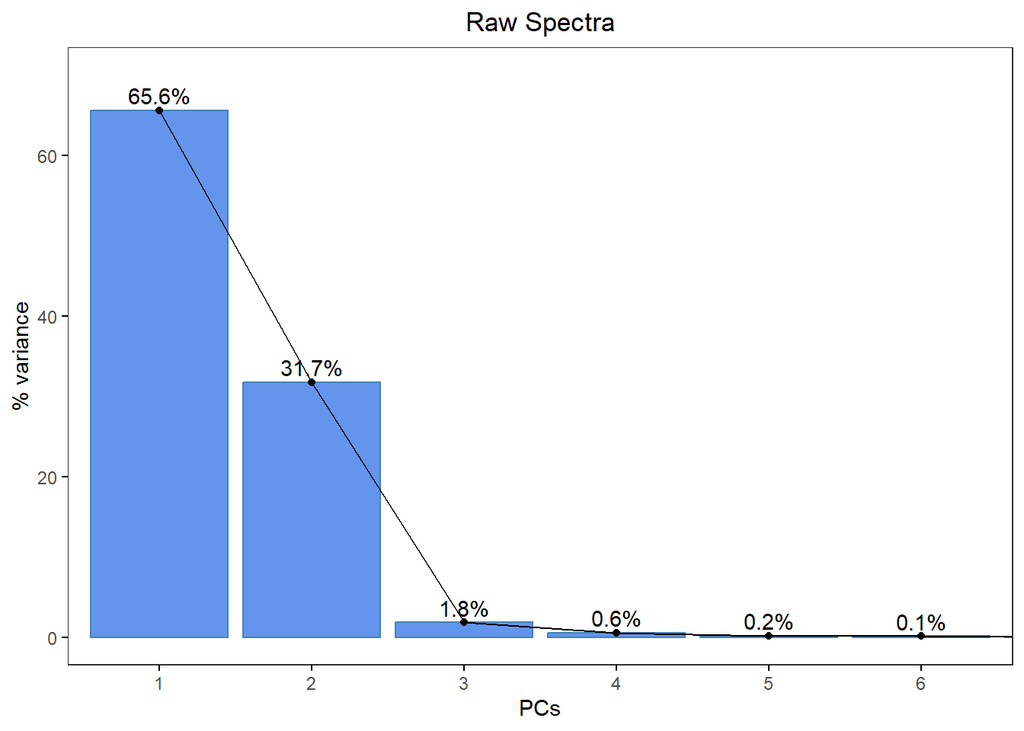

```r
# Scree Plot: Check the number of components to keep

fviz_eig(pca_raw, addlabels = TRUE, ylim = c(0, 70),
         xlim=c(1,6), main = 'Raw Spectra',barfill = "cornflowerblue",
         hjust = 0.5,
         ggtheme = theme_bw(),xlab = "PCs", ylab = "% variance")+
  theme(plot.title = element_text(hjust = 0.5))+
  theme(panel.grid = element_blank())
```

```r
# The elbow is at PC2-----> To retain PC1 and PC2. However, we will most of the PCs and subsequently check if we lose precision when using either all the PCs or only those suggested by the elbow method in the subsequent supervised models.

# Save the PCs in a new data frame
Pcs_hsi_raw <- as.data.frame(pca_raw$ind$coord[,c(1:6)])
colnames(Pcs_hsi_raw) <- c("PC1","PC2","PC3","PC4","PC5","PC6")
Pcs_hsi_raw <- cbind(columns, Pcs_hsi_raw) # Bind with the columns from initial data--> with sample details
kable(head(Pcs_hsi_raw))
```

| sample_id | binary_class | three_class | adult_percent | cal_val | PC1 | PC2 | PC3 | PC4 | PC5 | PC6 |
| --- | --- | --- | --- | --- | --- | --- | --- | --- | --- | --- |
| Pure_Arabica_10 | pure_arabica | pure_arabica | 0 | 1 | 9.551566 | 13.26732 | 0.6525435 | 1.2566445 | -1.143945 | 0.0854714 |
| Pure_Arabica_3 | pure_arabica | pure_arabica | 0 | 1 | 8.780026 | 20.03452 | 0.6924415 | 0.3597407 | -1.427612 | 0.5730261 |
| Pure_Arabica_2 | pure_arabica | pure_arabica | 0 | 1 | 16.737292 | 18.74044 | 2.9525753 | 0.2477756 | -1.459986 | -0.3805914 |
| Pure_Arabica_2 | pure_arabica | pure_arabica | 0 | 1 | 4.069887 | 11.88874 | 1.1476004 | 1.3918031 | -1.808034 | -0.3846577 |
| Pure_Arabica_2 | pure_arabica | pure_arabica | 0 | 1 | 11.655970 | 16.62836 | 1.9071946 | 0.5583164 | -1.225740 | -0.3783204 |
| Pure_Arabica_25 | pure_arabica | pure_arabica | 0 | 2 | 8.907335 | 15.70847 | 1.0928471 | -0.1436962 | -2.068824 | -0.2779525 |

```r
#write.csv(Pcs_hsi_raw, file = "pcs_hsi_raw.csv", row.names = FALSE) #save PC data
```

**Insights**

- The first two principal components, **PC1 and PC2**, account for the vast majority of the variance (**97.33%**), making them critical for analysis.

#### **PCA Plot for HSI Raw Spectra**

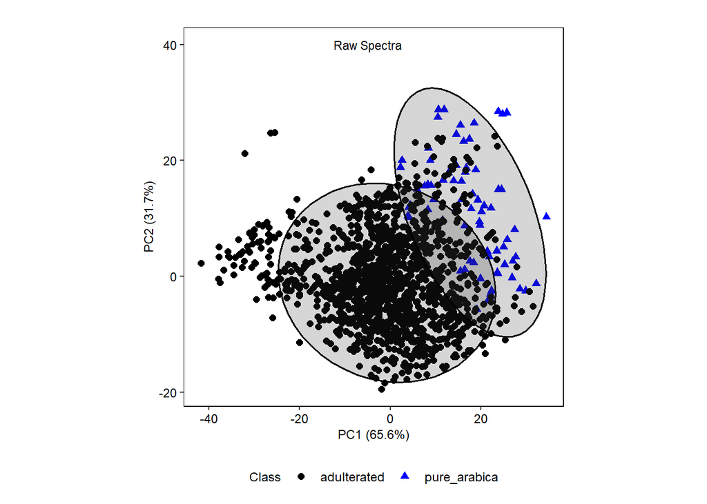

```r
# Raw spectra PCA Plot

Pcs_hsi_raw %>%
  ggplot(mapping = aes(x = PC1, y = PC2,
                       shape = as.factor(binary_class), color = binary_class)) +
  geom_point(size= 2) +
  labs(x = "PC1 (65.6%)", y = "PC2 (31.7%)",
       title = "",shape = "Class", color = "Class") +
  theme_bw() +
  theme(
    panel.border = element_rect(color = 'black', fill = NA),
    panel.grid = element_blank(),
    axis.text.x = element_text(color = 'black', size = 9),
    axis.text.y = element_text(color = 'black', size = 9),
    aspect.ratio = 1,
    axis.title.x = element_text(size = 9),
    axis.title.y = element_text(size = 9),
    plot.title = element_text(size = 9, hjust = 0.5),
    legend.title = element_text(size = 9),
    legend.text = element_text(size = 9),
    legend.position = "bottom"
  ) +
  scale_color_manual(values = c("pure_arabica" = "blue", "adulterated" = "black")) +
  stat_ellipse(aes(group = binary_class),
               level = 0.95,
               geom = "polygon", alpha = 0.2,
               color = 'black', linewidth = 0.6)+
   annotate("text", x = -5, y = 40, label = "Raw Spectra", size = 3, color = "black")
```

#### Check Important variables contributing to PC1 and PC2 for HSI Raw Spectra

```r
# Let us extract the loadings from the PCA
loadings <- pca_raw$var$coord

# Sort the loadings for PC1 and PC2
top_PC1 <- head(sort(abs(loadings[, 1]), decreasing = TRUE), 10) # Top 10 for PC1
top_PC2 <- head(sort(abs(loadings[, 2]), decreasing = TRUE), 10)  # Top 10 for PC2

# Combine into a data frame for easy viewing
top_PC1 <- as.data.frame(top_PC1)
top_PC2 <- as.data.frame(top_PC2)

# Display the top contributing variables
kable(top_PC1)
```

|  | top_PC1 |
| --- | --- |
| X1364.920044 | 0.9902321 |
| X1368.439941 | 0.9900957 |
| X1361.390015 | 0.9900693 |
| X1371.969971 | 0.9897523 |
| X1357.869995 | 0.9894548 |
| X1375.5 | 0.9891530 |
| X1354.349976 | 0.9884458 |
| X1379.02002 | 0.9880565 |
| X1350.819946 | 0.9868517 |
| X1382.550049 | 0.9853808 |

```r
kable(top_PC2)
```

|  | top_PC2 |
| --- | --- |
| X1580.98999 | 0.8077017 |
| X1584.550049 | 0.8073871 |
| X1577.430054 | 0.8073722 |
| X1573.869995 | 0.8071899 |
| X1588.109985 | 0.8067845 |
| X1570.310059 | 0.8062990 |
| X1591.670044 | 0.8053972 |
| X1595.22998 | 0.8044535 |
| X1566.75 | 0.8043830 |
| X1563.199951 | 0.8025520 |

- The region from **1350 to 1382** **nm** contributes most to the variation in PC1, while the region from **1563 to 1595 nm** contributes to PC2.